# ALY6040 M6 - Final Project Final Report

Instructor: Dr. Marcus Ellis

Student: Shahabaddin Feghahati

Completion Date: 03/31/2023

#### Introduction

The objective of this study is to create classification models using R that can accurately predict the credit status with 8 levels, ranging from paid off to payment delayed for 150 days or more. The process involves cleaning and preprocessing the data, performing exploratory data analysis, and splitting the data into train and test sets. The study also utilizes the SMOTE algorithm to balance the target class and trains various models such as SVM, decision tree, random forest, multinomial logistic regression, neural network, and K-Nearest Neighbors (KNN) models to compare their performance in predicting credit status. The random forest model demonstrated better performance among the other models, although it had poor overall accuracy and a low kappa statistic. Overall, this study effectively utilized several models to predict credit status, providing useful insights into their performance and identifying the most effective models for this task.

```r
library(data.table)
credit_data <- fread("credit_application.csv")

# Remove the FLAG_MOBIL column
credit_data <- subset(credit_data, select = -FLAG_MOBIL)

# remove rows with NAs
credit_data <- na.omit(credit_data)

# convert categorical variables to numerical representation
credit_data[, `:=`(
  CODE_GENDER = as.integer(factor(CODE_GENDER, levels = c("M", "F"), labels = c(1, 0))),
  FLAG_OWN_CAR = as.integer(factor(FLAG_OWN_CAR, levels = c("Y", "N"), labels = c(1, 0))),
  FLAG_OWN_REALTY = as.integer(factor(FLAG_OWN_REALTY, levels = c("Y", "N"), labels = c(1, 0))),
  NAME_INCOME_TYPE = as.integer(factor(NAME_INCOME_TYPE)),
  NAME_EDUCATION_TYPE = as.integer(factor(NAME_EDUCATION_TYPE)),
  NAME_FAMILY_STATUS = as.integer(factor(NAME_FAMILY_STATUS)),
  NAME_HOUSING_TYPE = as.integer(factor(NAME_HOUSING_TYPE)),
  #FLAG_MOBIL = as.integer(factor(FLAG_MOBIL)),
  FLAG_WORK_PHONE = as.integer(factor(FLAG_WORK_PHONE)),
  FLAG_PHONE = as.integer(factor(FLAG_PHONE)),
  OCCUPATION_TYPE = as.integer(factor(OCCUPATION_TYPE))
)]

# encode target variable as factor and convert to numerical representation
credit_data[, STATUS := as.integer(factor(STATUS, levels = c("C", "X", "0", "1", "2", "3", "4", "5")))]

# Check the distribution of the target variable
table(credit_data$STATUS)
```

```
##
##      1      2      3      4      5      6      7      8
## 225994 101970 200603   6392    542    181    152   1087
```

```r
# check the first few rows of the modified data table
#head(credit_data)
```

The given distribution of the target variable ‘STATUS’ in the credit card dataset is imbalanced, as there are a significantly larger number of observations in some categories compared to others. Specifically, categories 1 and 3 (Paid off that month and Payment delayed for 1-29 days) make up the majority of the observations, while categories 4-8 (Payment delayed for 30-59 days, Payment delayed for 60-89 days, Payment delayed for 90-119 days, Payment delayed for 120-149 days, Payment delayed for 150 days or more) have much smaller numbers of observations.

Imbalanced data can create issues for predictive modeling and machine learning algorithms, as these models tend to perform poorly on rare events, and can be biased towards the majority class. Therefore, in situations where imbalanced data is encountered, various techniques such as oversampling, undersampling, or synthetic sampling can be used to balance the data and improve the performance of the predictive models.

##### Correlation-based Feature Selection in Credit Data Analysis

```r
# load required libraries
library(data.table)
library(e1071)

# calculate the correlation coefficients
#correlations <- cor(preproc_data)
correlations <- cor(credit_data)

# filter out variables with low correlation coefficients
high_corr_vars <- names(which(abs(correlations[, "STATUS"]) > 0.01))

# remove the target variable from the list of high correlation variables
high_corr_vars <- high_corr_vars[high_corr_vars != "STATUS"]

# create a new data table with the high correlation variables and the target variable
selected_vars <- c(high_corr_vars, "STATUS")
selected_data <- credit_data[, selected_vars, with = FALSE]
str(selected_data)
```

```
## Classes 'data.table' and 'data.frame':   536921 obs. of  10 variables:
##  $ AMT_INCOME_TOTAL    : num  112500 112500 112500 112500 112500 ...
##  $ NAME_INCOME_TYPE    : int  5 5 5 5 5 5 5 5 5 5 ...
##  $ NAME_FAMILY_STATUS  : int  2 2 2 2 2 2 2 2 2 2 ...
##  $ FLAG_PHONE          : int  1 1 1 1 1 1 1 1 1 1 ...
##  $ FLAG_EMAIL          : int  0 0 0 0 0 0 0 0 0 0 ...
##  $ YEARS_EMPLOYED      : num  3.1 3.1 3.1 3.1 3.1 ...
##  $ log_YEARS_EMPLOYED  : num  1.13 1.13 1.13 1.13 1.13 ...
##  $ log_AMT_INCOME_TOTAL: num  11.6 11.6 11.6 11.6 11.6 ...
##  $ MONTHS_BALANCE      : int  -28 -6 -29 0 -4 -12 -7 -5 -11 -20 ...
##  $ STATUS              : int  3 1 2 1 1 2 2 1 3 3 ...
##  - attr(*, ".internal.selfref")=<externalptr>
```

The code above loads the required libraries and performs correlation-based feature selection on a credit data set. The selected variables are filtered out based on a threshold value of correlation coefficients and a new data table is created with only the high correlation variables and the target variable. The resulting data table has 536921 observations and 10 variables, including variables related to income, family status, phone and email flags, employment years, log-transformed variables, and the target variable ‘STATUS’.

##### Apply standardization to the credit_data dataset

```r
# Load the necessary packages
library(caret)    # for data pre-processing
library(dplyr)    # for data manipulation

selected_data_ <- selected_data[, c("AMT_INCOME_TOTAL", "NAME_INCOME_TYPE", "NAME_FAMILY_STATUS", "FLAG_PHONE", "FLAG_EMAIL",
                                "YEARS_EMPLOYED", "log_YEARS_EMPLOYED", "log_AMT_INCOME_TOTAL", "MONTHS_BALANCE")]

# Create a pre-processing recipe for standardization
preproc_recipe <- preProcess(selected_data_, method = c("center", "scale"))

# Apply the pre-processing recipe to the selected_data
preproc_data <- predict(preproc_recipe, selected_data_)

# Add STATUS back to the pre-processed data
preproc_data$STATUS <- selected_data$STATUS
```

##### Split the data into training and testing sets while handling the imbalanced dataset

```r
library(caret)

# Set the seed for reproducibility
set.seed(123)

# Split the data into 80% training and 20% testing sets, with stratified sampling based on "STATUS"
train_idx <- createDataPartition(preproc_data$STATUS, p = 0.8, list = FALSE, times = 1)

# Create the training and testing sets
train_data <- preproc_data[train_idx, ]
test_data <- preproc_data[-train_idx, ]
```

The code above splits the preprocessed data into training and testing sets, using stratified sampling based on the target variable ‘STATUS’. The training set contains 80% of the data and is stored as ‘train_data’, while the testing set contains 20% of the data and is stored as ‘test_data’.

##### Create a bar chart that shows the class distribution of the STATUS variable in the training and testing sets

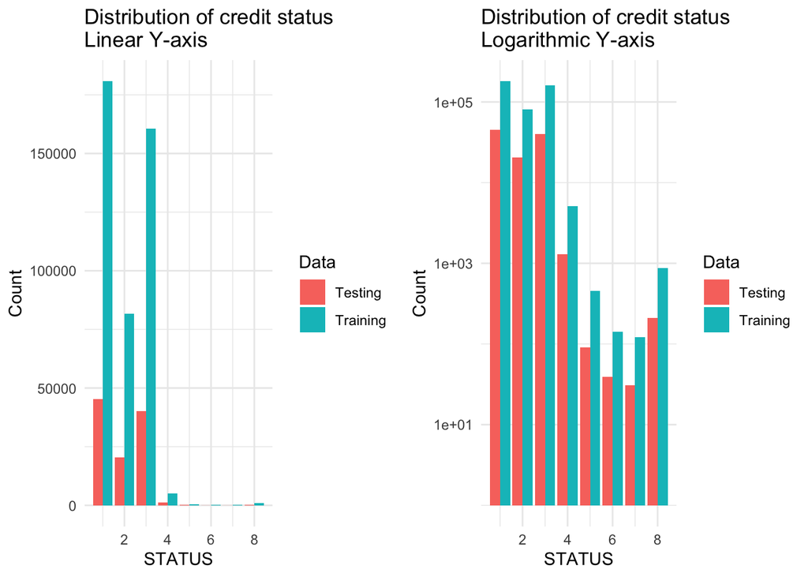

```r
library(ggplot2)
library(gridExtra)

# Combine the training and testing sets for plotting
combined_data <- rbind(train_data, test_data)

# Create a factor variable to specify the training/testing status of each observation
combined_data$Data <- ifelse(row.names(combined_data) %in% row.names(train_data), "Training", "Testing")
combined_data$Data <- as.factor(combined_data$Data)

# Linear Y-axis plot
plot1 <- ggplot(combined_data, aes(x = STATUS, fill = Data)) +
  geom_bar(position = "dodge") +
  labs(title = "Distribution of credit status\nLinear Y-axis", x = "STATUS", y = "Count") +
  theme_minimal() +
  scale_y_continuous(trans = "identity")

# Logarithmic Y-axis plot
plot2 <- ggplot(combined_data, aes(x = STATUS, fill = Data)) +
  geom_bar(position = "dodge") +
  labs(title = "Distribution of credit status\nLogarithmic Y-axis", x = "STATUS", y = "Count") +
  theme_minimal() +
  scale_y_continuous(trans = "log10")

# Combine plots side by side
grid.arrange(plot1, plot2, ncol = 2)
```

In both the training and testing sets, class 1 has the highest frequency, followed by class 3 and then class 2. Classes 4 to 8 have much lower frequencies than the first three classes.

These class frequencies can provide some insights into the distribution of the target variable and the balance of the dataset. It appears that the dataset is imbalanced, with classes 1, 2, and 3 having much higher frequencies than the other classes. This may need to be taken into account when developing a predictive model, as it could affect the performance of the model. Techniques such as oversampling or undersampling can be used to balance the dataset and improve the model’s performance.

It is generally recommended to perform oversampling or any other data preprocessing steps after splitting the data into training and testing sets. This is because oversampling the minority class(es) before splitting the data can result in the same observations being present in both the training and testing sets.

Having the same observations in both the training and testing sets can lead to overfitting and unrealistic estimates of model performance. Therefore, it is important to ensure that the training and testing sets are independent and identically distributed.

In the code provided earlier, oversampling is applied to the train_data dataset after it has been split from the original data using createDataPartition. This helps ensure that the oversampled data is used only for training the model, and that the testing set is not influenced by the oversampling process.

```r
# Convert the response variable to a factor variable
train_data$STATUS <- as.factor(train_data$STATUS)
test_data$STATUS <- as.factor(test_data$STATUS)
```

##### Use SMOTE to oversample the minority classes

```r
# Load the necessary packages
#installed.packages('DMwR')
#install.packages(c('xts', 'quantmod', 'ROCR'))
#install.packages ( "/Users/sf/Downloads/DMwR_0.4.1.tar.gz", repos=NULL, type="source", dependencies = TRUE)

library(DMwR)

# Check the distribution of the target variable
table(train_data$STATUS)
```

```
##
##      1      2      3      4      5      6      7      8
## 180803  81569 160483   5091    452    142    121    878
```

```r
# Over-sample the minority classes using SMOTE
train_data_balanced <- SMOTE(STATUS ~ ., train_data, perc.over = 1500, k = 8)

# Perform undersampling to balance the dataset
#train_data_balanced <- downSample(x = train_data[, -10], y = train_data[, 10])
#train_data_balanced <- downSample(formula = STATUS ~ ., data = train_data, yname = "STATUS")
#train_data_balanced <- cbind(train_data_balanced$x, STATUS = train_data_balanced$y)

# Apply ADASYN algorithm to balance the dataset
#train_data_balanced <- adasyn(train_data[, -STATUS], train_data$STATUS)

# Check the distribution of the target variable after balancing
table(train_data_balanced$STATUS)
```

```
##
##    1    2    3    4    5    6    7    8
## 1529  682 1372   31    2    2 1936   12
```

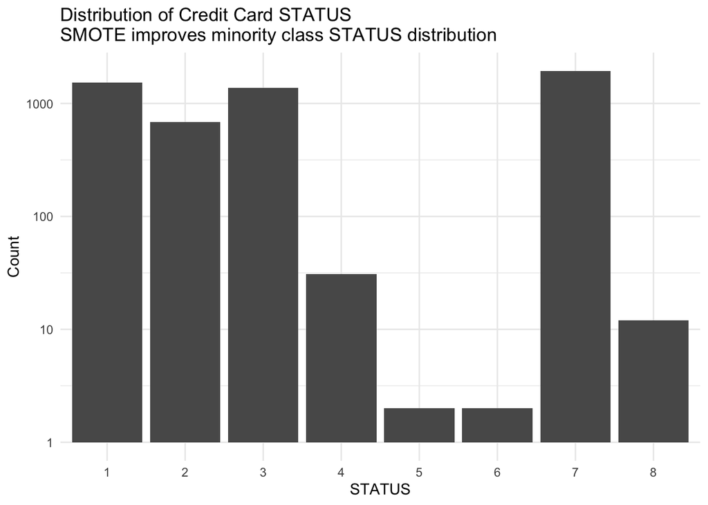

```r
# Create the bar chart
ggplot(data = train_data_balanced, aes(x = STATUS)) +
  geom_bar() +
  labs(title = "Distribution of Credit Card STATUS\nSMOTE improves minority class STATUS distribution", x = "STATUS", y = "Count") +
  scale_y_continuous(trans = "log10") +
  theme_minimal()
```

Here, perc.over is the percentage of oversampling, and k is the number of nearest neighbors to consider when generating synthetic samples. The result you provided shows the count of each class in the train_data_balanced dataset after applying SMOTE oversampling.

##### Training and Evaluating Machine Learning Models

```r
library(e1071)
library(rpart)
library(caret)
library(randomForest)
library(nnet)
library(ggplot2)

# Train and evaluate the SVM model
svm_model <- svm(STATUS ~ ., data = train_data_balanced, kernel = "radial", cost = 40)
svm_pred <- predict(svm_model, newdata = test_data)
svm_results <- confusionMatrix(svm_pred, test_data$STATUS)
svm_acc <- svm_results$overall["Accuracy"]
svm_kappa <- svm_results$overall["Kappa"]

# Train and evaluate the Decision Tree model
tree_model <- rpart(STATUS ~ ., data = train_data_balanced, method = "class")
tree_pred <- predict(tree_model, newdata = test_data, type = "class")
tree_results <- confusionMatrix(tree_pred, test_data$STATUS)
tree_acc <- tree_results$overall["Accuracy"]
tree_kappa <- tree_results$overall["Kappa"]

# Train and evaluate the Random Forest model
rf_model <- randomForest(STATUS ~ ., data = train_data_balanced)
rf_pred <- predict(rf_model, newdata = test_data)
rf_results <- confusionMatrix(rf_pred, test_data$STATUS)
rf_acc <- rf_results$overall["Accuracy"]
rf_kappa <- rf_results$overall["Kappa"]

# Train and evaluate the Multinomial Logistic Regression model
mlr_model <- multinom(STATUS ~ ., data = train_data_balanced)
mlr_pred <- predict(mlr_model, newdata = test_data)
mlr_results <- confusionMatrix(mlr_pred, test_data$STATUS)
mlr_acc <- mlr_results$overall["Accuracy"]
mlr_kappa <- mlr_results$overall["Kappa"]

# Train and evaluate the neural network model
nn_model <- train(STATUS ~ ., data = train_data_balanced, method = "nnet")
nn_pred <- predict(nn_model, newdata = test_data)
nn_results <- confusionMatrix(nn_pred, test_data$STATUS)
nn_acc <- nn_results$overall["Accuracy"]
nn_kappa <- nn_results$overall["Kappa"]

# Train and evaluate the K-Nearest Neighbors (KNN) model
knn_model <- train(STATUS ~ ., data = train_data_balanced, method = "knn")
knn_pred <- predict(knn_model, newdata = test_data)
knn_results <- confusionMatrix(knn_pred, test_data$STATUS)
knn_acc <- knn_results$overall["Accuracy"]
knn_kappa <- knn_results$overall["Kappa"]

# Create a data frame to store the accuracy and kappa values of all models
model_results <- data.frame(
  Model = c("Decision Tree", "Random Forest", "Multinomial Logistic Regression", "Neural Network", "K-Nearest Neighbors (KNN)", "Support Vector Machines (SVM)"),
  Accuracy = c(tree_acc, rf_acc, mlr_acc, nn_acc, knn_acc, svm_acc),
  Kappa = c(tree_kappa, rf_kappa, mlr_kappa, nn_kappa, knn_kappa, svm_kappa)
)
```

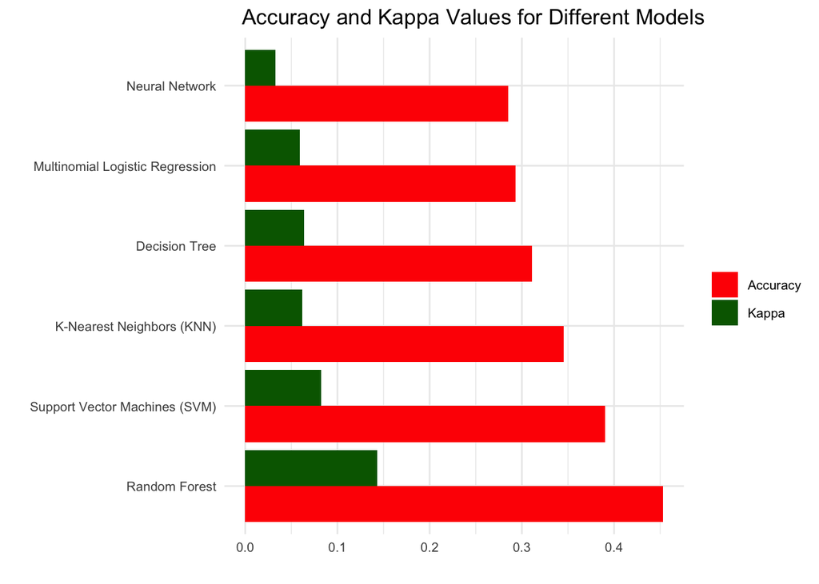

```r
library(tidyr)
library(ggplot2)

# Pivot the data frame to long format
model_results_long <- pivot_longer(model_results, cols = c(Accuracy, Kappa), names_to = "Metric", values_to = "Value")

# Create a bar plot to visualize the accuracy and kappa values of all models
ggplot(model_results_long, aes(x = reorder(Model, -Value), y = Value, fill = Metric)) +
  geom_bar(stat = "identity", position = "dodge") +
#  scale_fill_manual(values = c("#FFC300", "#900C3F"), name = "") +
  scale_fill_manual(values = c("#FF0000", "#006400"), name = "") +
#  scale_fill_manual(values = c("#EE7621", "#030303"), name = "") +
#  scale_fill_manual(values = c("#E6E6E6", "#3399FF"), name = "") +
#  scale_fill_manual(values = c("#999999", "#4D4D4D"), name = "") +

    labs(x = "", y = "") +
  ggtitle("   Accuracy and Kappa Values for Different Models") +
  theme(plot.title = element_text(hjust = 0.5)) +
  theme_minimal() +
  theme(axis.text.x = element_text(size = 8), axis.text.y = element_text(size = 8), legend.text = element_text(size = 8)) +
  theme(panel.background = element_blank()) +
  coord_flip()
```

In the given credit_application dataset, various machine learning models were applied to predict the credit status of the applicants. The models were evaluated based on their accuracy and kappa scores.

Kappa score is a statistical measure that assesses the agreement between the predicted and actual values of a classification model, taking into account the possibility of agreement occurring by chance. The accuracy of a classification model, on the other hand, is a measure of how often the model predicts the correct class label.

##### Delve into a more detailed evaluation of the random forest model

```r
# Train and evaluate the Random Forest model
rf_model <- randomForest(STATUS ~ ., data = train_data_balanced)
rf_pred <- predict(rf_model, newdata = test_data)
confusionMatrix(rf_pred, test_data$STATUS)
```

```
## Confusion Matrix and Statistics
##
##           Reference
## Prediction     1     2     3     4     5     6     7     8
##          1 27705  8928 17696   563    32     4     8    50
##          2  3347  3713  3304   105     6     1     1    16
##          3 12217  6713 17076   503    23     6     5    47
##          4    80    21    69    21     1     2     2     1
##          5     0     0     1     2     1     1     0     0
##          6     2     0     1     1     0     0     0     0
##          7  1836  1024  1963   105    27    25    15    86
##          8     4     2    10     1     0     0     0     9
##
## Overall Statistics
##
##                Accuracy : 0.452
##                  95% CI : (0.4491, 0.455)
##     No Information Rate : 0.4208
##     P-Value [Acc > NIR] : < 2.2e-16
##
##                   Kappa : 0.1419
##
##  Mcnemar's Test P-Value : NA
##
## Statistics by Class:
##
##                      Class: 1 Class: 2 Class: 3  Class: 4  Class: 5  Class: 6
## Sensitivity            0.6131  0.18200   0.4256 0.0161414 1.111e-02 0.000e+00
## Specificity            0.5613  0.92205   0.7099 0.9983409 1.000e+00 1.000e+00
## Pos Pred Value         0.5039  0.35385   0.4667 0.1065990 2.000e-01 0.000e+00
## Neg Pred Value         0.6663  0.82776   0.6745 0.9880580 9.992e-01 9.996e-01
## Prevalence             0.4208  0.18999   0.3736 0.0121156 8.381e-04 3.632e-04
## Detection Rate         0.2580  0.03458   0.1590 0.0001956 9.313e-06 0.000e+00
## Detection Prevalence   0.5121  0.09772   0.3407 0.0018346 4.656e-05 3.725e-05
## Balanced Accuracy      0.5872  0.55203   0.5678 0.5072412 5.055e-01 5.000e-01
##                       Class: 7  Class: 8
## Sensitivity          0.4838710 4.306e-02
## Specificity          0.9528090 9.998e-01
## Pos Pred Value       0.0029522 3.462e-01
## Neg Pred Value       0.9998436 9.981e-01
## Prevalence           0.0002887 1.946e-03
## Detection Rate       0.0001397 8.381e-05
## Detection Prevalence 0.0473171 2.421e-04
## Balanced Accuracy    0.7183400 5.215e-01
```

The results show the performance of the Random Forest model in predicting the credit card status of the test data set. The confusion matrix shows the number of correct and incorrect predictions for each class, where the rows represent the predicted classes and the columns represent the actual classes.

In summary, the Random Forest model does not perform very well in predicting the credit card status, especially for some of the classes. Therefore, the model may need to be improved by considering different features or using different modeling techniques to improve its performance.

#### CONCLUSION

The study aimed to predict credit status using different models, including SVM, decision tree, random forest, multinomial logistic regression, neural network, and K-nearest neighbors (KNN). The performance of these models was evaluated based on accuracy and kappa scores. Although the random forest model showed better performance than the rest of the models, it was observed to have poor overall accuracy, only slightly higher than the no-information rate. This suggested that the model’s performance was not much better than randomly guessing. Additionally, the Kappa statistic was low, indicating poor agreement between the predicted and actual classes.

Therefore, some recommendations for next actions are:

- Explore alternative classification models for better accuracy and sensitivity.
- Evaluate impact of feature engineering and selection on model performance.
- Gather more or diverse data to train more robust models.
- Use grid search to tune hyperparameters.
- Consider using ensemble techniques to improve accuracy and stability.

#### REFERENCES

Chen, C., Härdle, W., & Unwin, A. (2007). *Handbook of data visualization.* Springer.

Hastie, T., Tibshirani, R., & Friedman, J. (2009). *The Elements of Statistical Learning Data Mining, Inference, and Prediction* (Second Edition.). Springer New York. https://doi.org/10.1007/978-0-387-84858-7

Kabacoff, R. (2015). *R in action: data analysis and graphics with R* (Second edition.). Manning Publications.

Run R code online. (n.d.). Retrieved March 2, 2023, from https://rdrr.io/snippets/

Zach. (2021, February 22). *Cohen’s Kappa Statistic: Definition & Example.* Statology. https://www.statology.org/cohens-kappa-statistic/